# Lancet Lifespan - Example Solution

```r
lifespan_url <-
  "https://raw.githubusercontent.com/MarkWilcock/R-Course/main/Datasets/Longevity%20Data.csv"
lifespan_df <- read_csv(lifespan_url)
head(lifespan_df)
```

| Region | Country | Men 2010 | Men 2030 | Women 2010 | Women 2030 |
| --- | --- | --- | --- | --- | --- |
| Asia & Oceania | Australia | 80.10 (79.89-80.19) | 84.00 (80.27-87.95) | 84.53 (84.46-84.64) | 87.57 (84.86-90.43) |
| Western Europe | Austria | 77.73 (77.50-77.87) | 81.40 (78.56-85.40) | 83.21 (82.90-83.33) | 86.22 (81.65-88.32) |
| Western Europe | Belgium | 77.35 (77.07-77.46) | 80.88 (76.38-83.80) | 82.76 (82.57-82.87) | 85.64 (81.10-87.98) |
| Eastern Europe | Bulgaria | 70.21 (68.56-70.34) | 74.07 (67.88-80.80) | 77.33 (76.93-77.45) | 78.87 (77.51-84.06) |
| Americas | Canada | 79.41 (78.70-79.50) | 83.89 (80.01-87.87) | 83.94 (83.40-84.04) | 87.09 (84.11-90.02) |
| Americas | Chile | 76.74 (76.09-76.86) | 80.74 (76.23-84.05) | 82.95 (81.73-83.08) | 86.89 (80.71-90.20) |

Let’s reshape into a tidy format (Region Country, Gender, Year, Lifespan) and remove the confidence interval values. This isn’t a session on dplyr so we won’t go into detail.

```r
lifespan <-
  lifespan_df %>%
  gather(key = "GenderYear",
         value = "Lifespan",
         `Men 2010`,
         `Women 2010`,
         `Men 2030`,
         `Women 2030`) %>%
  separate(GenderYear, c("Gender", "Year")) %>%
  mutate(Lifespan = as.numeric(str_sub(Lifespan, 1, 4)))
head(lifespan_tidy)
```

| Region | Country | Gender | Year | Lifespan |
| --- | --- | --- | --- | --- |
| Asia & Oceania | Australia | Men | 2010 | 80.1 |
| Western Europe | Austria | Men | 2010 | 77.7 |
| Western Europe | Belgium | Men | 2010 | 77.3 |
| Eastern Europe | Bulgaria | Men | 2010 | 70.2 |
| Americas | Canada | Men | 2010 | 79.4 |
| Americas | Chile | Men | 2010 | 76.7 |

For our first charts we’ll focus on 2010 births

```r
lifespan_2010 <-
  lifespan %>%
  filter(Year == 2010) %>%
  select (-Year)

lifespan_2010_women <-
  lifespan_2010 %>%
  filter(Gender == 'Women') %>%
  select (-Gender)
```

*Exercise* Create bar chart to show expected lifespan of women born in 2010 born by country.

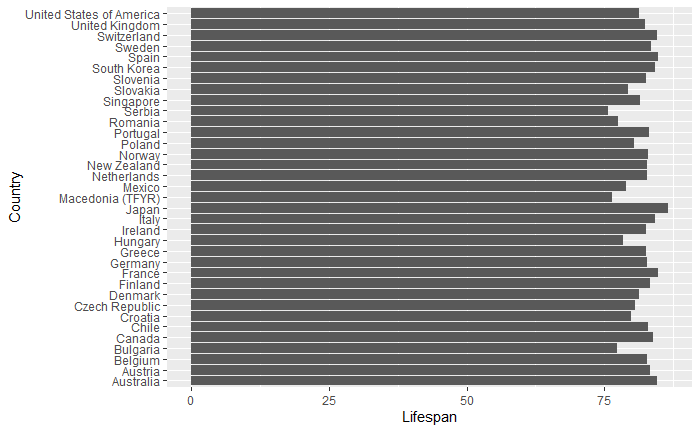

```r
ggplot(lifespan_2010_women,
       aes(x = Country, y = Lifespan)) +
  geom_col() +
  coord_flip()
```

*Exercise* Improve the chart, * perhaps use points rather than bars * order the countries by Lifespan so we get the values ordered from high to low * provide a better theme * start the Lifespan axis at a more appropriate value * give it a title and subtitle * remove the label on the Country axis

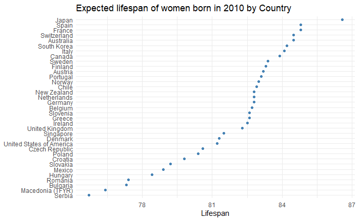

```r
ggplot(lifespan_2010_women,
       aes(x = fct_reorder(Country, Lifespan), y = Lifespan)) +
  geom_point(col = "steelblue") +
  coord_flip() +
  theme_minimal() +
  labs(title="Expected lifespan of women born in 2010 by Country") +
  scale_x_discrete(NULL)
```

Lets compare the lifespan of men and women born in 2010 by country. We need to reshape our dataset to have a Men and Women columns.

```r
lifespan_2010_reshape <-
  lifespan_2010  %>%
  spread(Gender, Lifespan)
lifespan_2010_reshape
```

| Region | Country | Men | Women |
| --- | --- | --- | --- |
| Americas | Canada | 79.4 | 83.9 |
| Americas | Chile | 76.7 | 82.9 |
| Americas | Mexico | 73.1 | 78.9 |
| Americas | United States of America | 76.5 | 81.2 |
| Asia & Oceania | Australia | 80.1 | 84.5 |
| Asia & Oceania | Japan | 79.4 | 86.6 |
| Asia & Oceania | New Zealand | 79.0 | 82.8 |
| Asia & Oceania | Singapore | 75.8 | 81.5 |
| Asia & Oceania | South Korea | 77.1 | 84.2 |
| Eastern Europe | Bulgaria | 70.2 | 77.3 |

[output cut: 25 more lines]

*Exercise* Create a scatter plot showing both men and women in 2010 and 2030 Use colour to distinguish between 2010 and 2030 births Use a scale for your colours

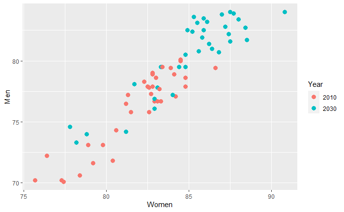

```r
ggplot(
  data = lifespan %>% spread(Gender, Lifespan),
       aes(x = Women, y = Men, col = Year)) +
  geom_point( size = 3) +
  scale_fill_brewer(type="seq", palette="Set3")
```

[figure not shown]

```r
lifespan_2010_reshape <- lifespan %>%  filter(Year == 2010) %>% spread(Gender, Lifespan)

ggplot(
  data = lifespan_2010_reshape,
       aes(x = Women, y = Men, col = Year)) +
  geom_point( size = 3) +
  scale_x_continuous(name="Women's Lifespan", limits = c(70, 90)) +
  scale_y_continuous(name="Men's Lifespan", limits = c(70, 90)) +
  geom_hline(yintercept = mean(lifespan_2010_reshape$Men), col="blue", linetype=2) +
  geom_vline(xintercept = mean(lifespan_2010_reshape$Women), col="blue", linetype=2)  +
  geom_abline(slope = 1, intercept = 0)
```

For the next chart, we *don’t* want the data 100% tidy. We want to pivot so that we have a 2010 and 2030 column

```r
lifespan_change <-
lifespan %>%
  spread(Year, Lifespan) %>%
  mutate(Change = `2030` - `2010`)

lifespan_change_women <-
  lifespan_change %>%
  filter(Gender=="Women")

lifespan_change_women
```

| Region | Country | Gender | 2010 | 2030 | Change |
| --- | --- | --- | --- | --- | --- |
| Americas | Canada | Women | 83.9 | 87.0 | 3.1 |
| Americas | Chile | Women | 82.9 | 86.8 | 3.9 |
| Americas | Mexico | Women | 78.9 | 82.9 | 4.0 |
| Americas | United States of America | Women | 81.2 | 83.3 | 2.1 |
| Asia & Oceania | Australia | Women | 84.5 | 87.5 | 3.0 |
| Asia & Oceania | Japan | Women | 86.6 | 88.4 | 1.8 |
| Asia & Oceania | New Zealand | Women | 82.8 | 85.9 | 3.1 |
| Asia & Oceania | Singapore | Women | 81.5 | 84.8 | 3.3 |
| Asia & Oceania | South Korea | Women | 84.2 | 90.8 | 6.6 |
| Eastern Europe | Bulgaria | Women | 77.3 | 78.8 | 1.5 |

[output cut: 25 more lines]

*Exercise* Create a dumbbell plot, using geom_dumbbell() from the ggalt package.

Arrange these countries in ascending order of lifespan for 2010 women births Hint:

```r
lifespan_change_women <-
  lifespan_change_women %>%
  mutate(CountryF = fct_reorder(Country, `2010`))

print(str(lifespan_change_women$Country)) # a character vector in alphabetical order
print(str(lifespan_change_women$CountryF)) # a factor ordered by 2010 Lifespan
```

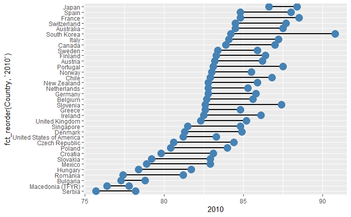

```r
ggplot(lifespan_change_women, aes(x = `2010`, xend = `2030`, y = fct_reorder(Country, `2010`) )) +
  geom_dumbbell(colour_x ="steelblue", colour_xend = "steelblue", size = 1, size_x = 5, size_xend = 5)
```

*Exercise*

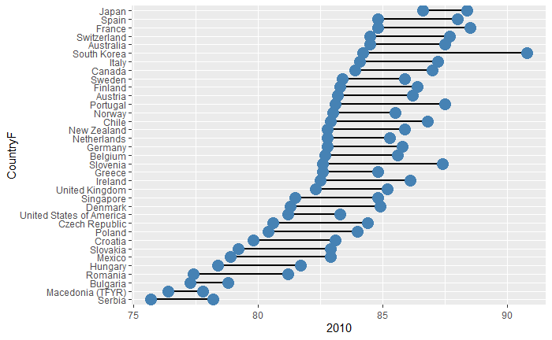

```r
ggplot(lifespan_change_women,
       aes(
         x = `2010`,
         xend = `2030`,
         y = CountryF
       )) +
  geom_dumbbell(
    colour_x = "steelblue",
    colour_xend = "steelblue",
    size = 1,
    size_x = 5,
    size_xend = 5
  )
```

*Exercise*

Improve the chart above to make it more appealing Use ggplot capabilities including labels, titles, themes, scales

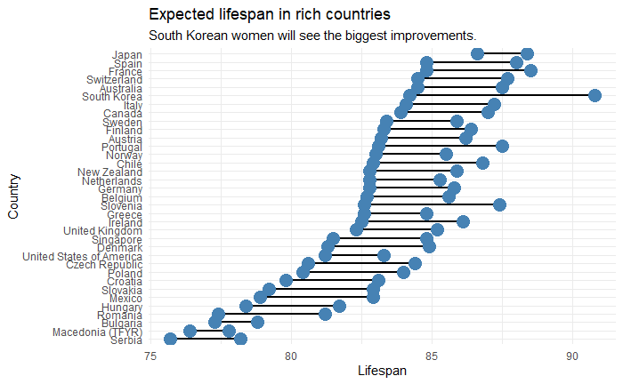

```r
ggplot(lifespan_change_women,
       aes(
         x = `2010`,
         xend = `2030`,
         y = fct_reorder(Country, `2010`)
       )) +
  geom_dumbbell(
    colour_x = "steelblue",
    colour_xend = "steelblue",
    size = 1,
    size_x = 5,
    size_xend = 5
  ) +
  theme_minimal() +
  ggtitle(
    "Expected lifespan in rich countries",
    "South Korean women will see the biggest improvements."
  ) +
  scale_y_discrete("Country") +
  scale_x_continuous("Lifespan")
```

For the next chart, you may need the CountryFMen2010 factor variable, created below

```r
lifespan_change<-
  lifespan_change %>%
  mutate(
    Men2010 = ifelse(Gender == 'Men', `2010`, NA),
    CountryFMen2010 =  fct_reorder(Country, Men2010, na.rm = TRUE)
  ) %>%
  select(-Men2010) # we no longer need this so remove it
```

Add faceting to show small multiple charts by region and by gender

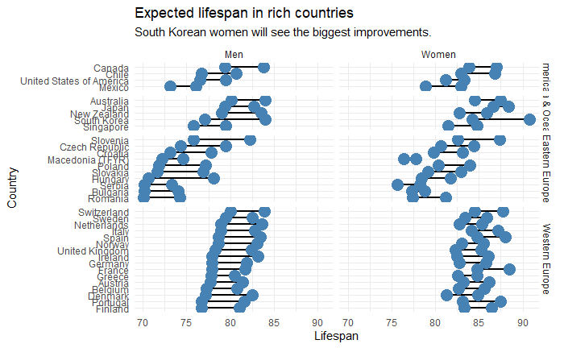

```r
ggplot(lifespan_change, aes(
  x = `2010`,
  xend = `2030`,
  y = CountryFMen2010
)) +
  geom_dumbbell(
    colour_x = "steelblue",
    colour_xend = "steelblue",
    size = 1,
    size_x = 5,
    size_xend = 5
  ) +
  theme_minimal() +
  #theme(panel.background = element_rect(fill="lightyellow")) +
  facet_grid(Region ~ Gender, scales = "free_y", space = "free_y") +
  ggtitle(
    "Expected lifespan in rich countries",
    "South Korean women will see the biggest improvements."
  ) +
  scale_y_discrete("Country") +
  scale_x_continuous("Lifespan")
```